# Policy Influence: Do Public Pressure Campaigns Influence Bureaucratic Policymaking?

Appendix and Replication Code

Devin Judge-Lord

# 1 Data

Replication data are available in SQL and Rdata at https://github.com/judgelord/rulemaking

These data currently include 212,516 dockets, 134,927 rulemaking dockets from 1,909-02-10 to 2,020-12-17. These dockets received approximately 99,329,768 comments.

This analysis relies of rulemaking dockets from 2005 through 2020. These 44,583 rulemaking dockets received 75,614,762 comments.

## 1.1 Comments from legislators

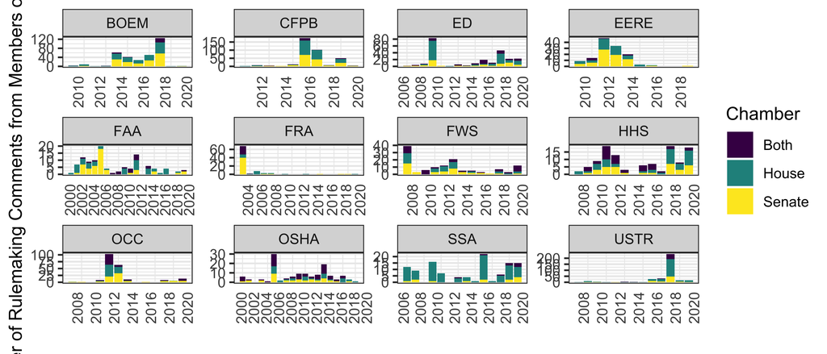

Figure 1.1: Number of Letters from Members of Congress Received During Rulemaking per Year

## 1.2 Hand-coded sample

My approach of identifying the dimensions of the conflict by comments has benefits and downsides. Compared to other potentail measures of success, it is more likely to focus on things that commenters care about. For example, one could measure success by the number of times a comment is mentioned in the agency’s response to comments. However, this may capture stratigic responsiveness by agencies choosing to discuss some issues more than others. It also counts explicit rejections toward the measure of responsiveness. One could also measure success by focusing on a-priory potential aspects of the policy. @Balla2020 count five factors: (1) the number of regulated entities, (2) number of activities or substances being regulated, (3) the level of pollution standards, (4) the compliance and effective deadlines of the regulation, and (5) the monitoring and reporting requirements. Each takes one value (increasing or decreasing) and each is weighted equally in the analysis. In contrast, starting with comments allows commenters to highlight the issues they care most about.

### 1.2.1 By organization

| org_type | n |
| --- | --- |
| ngo | 1523 |
| gov | 767 |
| corp group | 529 |
| corp | 512 |
| NA | 23 |
| org | 8 |
| corp groups | 4 |
| elected | 3 |
| corp gorup | 1 |
| corp grop | 1 |
| courp group | 1 |
| general assembly-md | 1 |
| gov association | 1 |
| maryland house of delegates | 1 |
| new jersey mayor | 1 |
| ngos | 1 |
| other | 1 |
| senate-md | 1 |

| org_type_detailed | n |
| --- | --- |
| ngo;advocacy | 341 |
| gov;local | 293 |
| gov;state | 211 |
| ngo;ngo | 207 |
| ngo;legal | 70 |
| corp;group | 66 |
| ngo;credit union | 60 |
| ngo;professional | 58 |
| ngo; advocacy | 48 |
| ngo;university | 47 |
| gov;tribe | 44 |
| gov;tribe;ej | 42 |
| ngo;ngo;advocacy | 39 |
| corp;corp | 37 |
| gov;federal | 33 |
| ngo;union | 33 |
| ngo;faith | 32 |
| ngo;coalition | 29 |
| gov;federal;regional | 25 |
| corp;energy | 21 |
| gov;local;coalition | 20 |
| corp;law firm | 18 |
| ngo;thinktank | 18 |
| corp group;coalition | 17 |
| ngo;membership | 17 |
| ngo;ngo;pressure group | 16 |
| corp;bank | 14 |
| corp;small corp | 14 |
| ngo;legal;advocacy | 14 |
| ngo;advocacy;membership | 12 |

[output cut: 70 more lines]

| elected_type | n |
| --- | --- |
| house | 30 |
| senate | 20 |
| gov | 6 |
| mayor | 6 |
| alaska | 5 |
| congress | 5 |
| florida | 4 |
| maryland | 4 |
| mississippi | 4 |
| representative | 4 |
| NA | 4 |
| california | 3 |
| city | 3 |
| governor | 3 |
| illinois | 3 |
| senator | 3 |
| senators | 3 |
| texas | 3 |
| baltimore | 2 |
| carbondale | 2 |
| carver | 2 |
| new | 2 |
| ohio | 2 |
| oklahoma | 2 |
| pennsylvania | 2 |
| attorney | 1 |
| berkeley | 1 |
| elected | 1 |
| georgia | 1 |
| iowa | 1 |
| jersey | 1 |
| kentucky | 1 |
| linda | 1 |
| ma | 1 |
| member | 1 |
| missouri | 1 |
| mt | 1 |
| nebraska | 1 |
| north | 1 |
| rosemead | 1 |
| santa | 1 |
| south | 1 |
| state | 1 |
| tennessee | 1 |

### 1.2.2 By coalition

Sample of coalition-level data:

| docket_id | coalition_comment | coalition_type | coalitions | coalition_unopposed | coalition_congress | coalition_size | coalition_position | coalition_business | coalition_success | coalition_leader_success | coalition_comments | coalition_id | Coalition_size | coalition |
| --- | --- | --- | --- | --- | --- | --- | --- | --- | --- | --- | --- | --- | --- | --- |
| BSEE-2012-0005 | environmental | public | 7 | FALSE | 0 | 4 | 4.750000 | 0 | 1.5000000 | 1.5000000 | 1530 | 81 | 2-10 | environmental |
| BSEE-2012-0005 | pew | public | 7 | FALSE | 0 | 4 | 4.750000 | 0 | 1.5000000 | 1.5000000 | 1530 | 186 | 2-10 | pew |
| BSEE-2013-0010 | energy industry | private | 2 | TRUE | 0 | 1 | 1.000000 | 0 | -2.0000000 | -2.0000000 | 1 | 79 | 1 | energy industry |
| BSEE-2013-0010 | shell | private | 2 | TRUE | 0 | 1 | 1.000000 | 0 | -2.0000000 | -2.0000000 | 1 | 202 | 1 | shell |
| BSEE-2013-0011 | energy industry | private | 6 | FALSE | 7 | 90 | 2.244444 | 29 | -1.2727273 | -1.2727273 | 90 | 79 | 11-100 | energy industry |
| BSEE-2013-0011 | shell | private | 6 | FALSE | 7 | 90 | 2.244444 | 29 | -1.2727273 | -2.0000000 | 90 | 202 | 11-100 | shell |
| BSEE-2018-0002 | environmental | public | 6 | FALSE | 3 | 27 | 1.074074 | 0 | -1.8947368 | -1.8947368 | 71627 | 81 | 11-100 | environmental |
| BSEE-2018-0002 | earthjustice | public | 6 | FALSE | 3 | 27 | 1.074074 | 0 | -1.8947368 | -2.0000000 | 71627 | 71 | 11-100 | earthjustice |
| CEQ-2019-0003 | partnership project | public | 6 | FALSE | 1 | 135 | 1.148148 | 0 | -1.7647059 | -2.0000000 | 400081 | 185 | More than 100 | partnership project |
| CEQ-2019-0003 | liuna | private | 6 | FALSE | 0 | 112 | 4.526786 | 1 | 0.5333333 | 0.5333333 | 2884 | 121 | More than 100 | liuna |
| CFPB-2016-0025 | wcbc | public | 6 | FALSE | 5 | 148 | 4.831081 | 4 | 0.7627119 | 0.7627119 | 148 | 234 | More than 100 | wcbc |
| CFPB-2016-0025 | axcess financial | private | 6 | FALSE | 3 | 109 | 1.321101 | 57 | -0.6029412 | -1.0000000 | 109 | 29 | More than 100 | axcess financial |
| CFPB-2019-0006 | true | public | 14 | FALSE | 0 | 54 | 1.648148 | 2 | -1.3400000 | -1.3400000 | 54 | 222 | 11-100 | true |
| CFPB-2019-0006 | true | NA | 14 | FALSE | 0 | 54 | 1.648148 | 2 | -1.3400000 | -1.3400000 | 54 | 222 | 11-100 | true |
| CFPB-2019-0006 | true | private | 14 | FALSE | 0 | 54 | 1.648148 | 2 | -1.3400000 | -1.3400000 | 54 | 222 | 11-100 | true |
| CFPB-2019-0022 | lshv | public | 5 | FALSE | 3 | 79 | 1.227848 | 4 | -0.6086957 | -0.6086957 | 79 | 123 | 11-100 | lshv |
| CFPB-2019-0022 | aca international | private | 5 | FALSE | 0 | 45 | 4.311111 | 36 | 0.6875000 | 0.5000000 | 45 | 2 | 11-100 | aca international |
| DOI-2015-0005 | blanket crew | public | 6 | FALSE | 0 | 14 | 4.071429 | 1 | 2.0000000 | 2.0000000 | 14 | 35 | 11-100 | blanket crew |
| DOI-2015-0005 | support and assist | public | 6 | FALSE | 0 | 11 | 4.727273 | 0 | 2.0000000 | 2.0000000 | 11 | 213 | 11-100 | support and assist |
| ED-2016-OESE-0032 | parent teacher association | public | 12 | FALSE | 0 | 7 | 5.000000 | 1 | 1.0000000 | 1.0000000 | 7 | 184 | 2-10 | parent teacher association |
| ED-2016-OESE-0032 | global down syndrome foundation | public | 12 | FALSE | 0 | 3 | 4.333333 | 0 | 1.0000000 | 1.0000000 | 3 | 103 | 2-10 | global down syndrome foundation |
| FEMA-2016-0003 | pew | public | 10 | FALSE | 0 | 223 | 4.103139 | 1 | -1.8918919 | -1.8918919 | 2982 | 186 | More than 100 | pew |
| FEMA-2016-0003 | nema | public | 10 | FALSE | 0 | 44 | 2.886364 | 2 | 1.0000000 | 1.0000000 | 44 | 159 | 11-100 | nema |
| FWS-HQ-ES-2018-0006 | defenders of wildlife | public | 5 | FALSE | 0 | 108 | 1.138889 | 0 | -1.6666667 | -2.0000000 | 440844 | 63 | More than 100 | defenders of wildlife |
| FWS-HQ-ES-2018-0006 | national endangered species act reform coalition | private | 5 | FALSE | 1 | 76 | 4.197368 | 36 | 0.2222222 | -2.0000000 | 76 | 149 | 11-100 | national endangered species act reform coalition |
| FWS-HQ-ES-2018-0007 | defenders of wildlife | public | 4 | FALSE | 0 | 98 | 1.122449 | 0 | -1.6938776 | -1.6938776 | 702687 | 63 | 11-100 | defenders of wildlife |
| FWS-HQ-ES-2018-0007 | national endangered species act reform coalition | private | 4 | FALSE | 0 | 74 | 4.148649 | 36 | 1.9629630 | 2.0000000 | 74 | 149 | 11-100 | national endangered species act reform coalition |
| FWS-HQ-ES-2018-0097 | environmentalists | public | 9 | FALSE | 0 | 62 | 1.193548 | 0 | -1.3255814 | -1.3255814 | 856517 | 85 | 11-100 | environmentalists |
| FWS-HQ-ES-2018-0097 | center for biological diversity | public | 9 | FALSE | 0 | 62 | 1.193548 | 0 | -1.3255814 | -2.0000000 | 856517 | 41 | 11-100 | center for biological diversity |
| FWS-HQ-NWRS-2012-0086 | defenders of wildlife | public | 3 | FALSE | 0 | 13 | 4.692308 | 0 | 0.6363636 | 0.6363636 | 53271 | 63 | 11-100 | defenders of wildlife |
| FWS-HQ-NWRS-2012-0086 | alaska oil and gas association | private | 3 | FALSE | 0 | 5 | 1.800000 | 3 | -0.4000000 | -2.0000000 | 5 | 9 | 2-10 | alaska oil and gas association |
| FWS-R9-ES-2008-0093 | earthjustice | public | 4 | FALSE | 0 | 58 | 1.051724 | 0 | -1.7826087 | -1.7826087 | 58 | 71 | 11-100 | earthjustice |
| FWS-R9-ES-2008-0093 | national endangered species act reform coalition | private | 4 | FALSE | 0 | 21 | 4.333333 | 8 | 0.2857143 | 2.0000000 | 21 | 149 | 11-100 | national endangered species act reform coalition |
| ICEB-2015-0002 | nafsa | public | 6 | FALSE | 1 | 108 | 4.435185 | 10 | 1.1607143 | 1.1607143 | 108 | 142 | More than 100 | nafsa |
| ICEB-2015-0002 | afl-cio | public | 6 | FALSE | 0 | 5 | 5.000000 | 2 | 0.8000000 | 0.8000000 | 5 | 6 | 2-10 | afl-cio |
| IRS-2016-0015 | americans for tax fairness | public | 4 | FALSE | 0 | 9 | 4.888889 | 0 | 2.0000000 | 2.0000000 | 29853 | 19 | 2-10 | americans for tax fairness |
| IRS-2016-0015 | congressmen | public | 4 | FALSE | 1 | 1 | 4.000000 | 0 | -2.0000000 | -2.0000000 | 1 | 55 | 1 | congressmen |
| IRS-2016-0015 | small businesses | public | 4 | FALSE | 0 | 1 | 4.000000 | 0 | 2.0000000 | 2.0000000 | 1 | 205 | 1 | small businesses |
| IRS-2016-0015 | swiss re | private | 4 | FALSE | 0 | 1 | 3.000000 | 0 | -1.0000000 | -1.0000000 | 1 | 215 | 1 | swiss re |
| MSHA-2011-0001 | wyoming mining association | private | 3 | FALSE | 0 | 41 | 2.219512 | 0 | -1.4500000 | -2.0000000 | 41 | 240 | 11-100 | wyoming mining association |
| MSHA-2011-0001 | united mine workers of america | public | 3 | FALSE | 1 | 4 | 4.500000 | 0 | 0.5000000 | -1.0000000 | 4 | 228 | 2-10 | united mine workers of america |
| NOAA-NMFS-2008-0096 | environmental community | public | 13 | FALSE | 0 | 20 | 4.950000 | 0 | -0.9090909 | -0.9090909 | 20 | 83 | 11-100 | environmental community |
| NOAA-NMFS-2008-0096 | commercial fishers and processors | private | 13 | FALSE | 0 | 13 | 2.692308 | 6 | -0.2857143 | -0.2857143 | 13 | 49 | 11-100 | commercial fishers and processors |
| NOAA-NMFS-2011-0117 | environmental | public | 5 | FALSE | 0 | 6 | 5.000000 | 0 | -1.0000000 | -1.0000000 | 12887 | 81 | 2-10 | environmental |
| NOAA-NMFS-2011-0117 | oceana | public | 5 | FALSE | 0 | 6 | 5.000000 | 0 | -1.0000000 | -2.0000000 | 12887 | 174 | 2-10 | oceana |
| NOAA-NMFS-2012-0059 | environmental | public | 7 | FALSE | 0 | 39 | 1.000000 | 1 | -1.6666667 | -1.6666667 | 102874 | 81 | 11-100 | environmental |
| NOAA-NMFS-2012-0059 | pew | public | 7 | FALSE | 0 | 39 | 1.000000 | 1 | -1.6666667 | -1.6666667 | 102874 | 186 | 11-100 | pew |
| NOAA-NMFS-2013-0050 | environmental | public | 9 | FALSE | 0 | 12 | 1.000000 | 1 | -1.3333333 | -1.3333333 | 74818 | 81 | 11-100 | environmental |
| NOAA-NMFS-2013-0050 | pew | public | 9 | FALSE | 0 | 12 | 1.000000 | 1 | -1.3333333 | -1.3333333 | 74818 | 186 | 11-100 | pew |
| NOAA-NMFS-2013-0101 | pew charitable trusts | public | 5 | FALSE | 0 | 132 | 4.984849 | 1 | -0.5625000 | -1.5000000 | 168292 | 188 | More than 100 | pew charitable trusts |
| NOAA-NMFS-2013-0101 | american sportfishing association | private | 5 | FALSE | 0 | 5 | 5.000000 | 1 | 0.0000000 | -2.0000000 | 1542 | 18 | 2-10 | american sportfishing association |
| NOAA-NMFS-2018-0035 | environment | public | 6 | FALSE | 0 | 18 | 1.000000 | 0 | -1.9000000 | -1.9000000 | 28488 | 80 | 11-100 | environment |
| NOAA-NMFS-2018-0035 | gulf restoration network | public | 6 | FALSE | 0 | 18 | 1.000000 | 0 | -1.9000000 | -2.0000000 | 28488 | 109 | 11-100 | gulf restoration network |
| NOAA-NMFS-2018-0035-0326 | environment | public | 2 | TRUE | 0 | 1 | 1.000000 | 0 | NaN | NaN | 652 | 80 | 1 | environment |
| NOAA-NMFS-2018-0035-0326 | gulf restoration network | public | 2 | TRUE | 0 | 1 | 1.000000 | 0 | NaN | NaN | 652 | 109 | 1 | gulf restoration network |
| NOAA-NOS-2013-0091 | environmental | public | 5 | FALSE | 1 | 19 | 4.263158 | 1 | 2.0000000 | 2.0000000 | 19 | 81 | 11-100 | environmental |
| NOAA-NOS-2013-0091 | national marine sanctuary foundation | public | 5 | FALSE | 1 | 19 | 4.263158 | 1 | 2.0000000 | 2.0000000 | 19 | 151 | 11-100 | national marine sanctuary foundation |
| NPS-2018-0007 | aclu | public | 4 | FALSE | 1 | 76 | 1.013158 | 0 | 1.9672131 | 1.9672131 | 76 | 4 | 11-100 | aclu |
| NPS-2018-0007 | smithsonian | public | 4 | FALSE | 0 | 3 | 1.333333 | 0 | 2.0000000 | 2.0000000 | 3 | 206 | 2-10 | smithsonian |
| OCC-2020-0026 | aclu | public | 3 | FALSE | 7 | 77 | 1.000000 | 0 | -1.9523810 | -1.9523810 | 222 | 4 | 11-100 | aclu |
| OCC-2020-0026 | mla | private | 3 | FALSE | 0 | 12 | 3.916667 | 8 | 2.0000000 | 2.0000000 | 12 | 134 | 11-100 | mla |
| OFCCP-2014-0004 | aclu | public | 4 | FALSE | 0 | 166 | 4.000000 | 0 | -2.0000000 | -2.0000000 | 7151 | 4 | More than 100 | aclu |
| OFCCP-2014-0004 | u.s. chamber of commerce | private | 4 | FALSE | 0 | 13 | 1.000000 | 0 | 1.6923077 | 2.0000000 | 13 | 223 | 11-100 | u.s. chamber of commerce |
| OSHA-H005C-2006-0870 | newport news | public | 5 | FALSE | 2 | 30 | 4.833333 | 0 | 1.0357143 | 1.0357143 | 30 | 163 | 11-100 | newport news |
| OSHA-H005C-2006-0870 | southern company | public | 5 | FALSE | 0 | 15 | 3.000000 | 0 | 0.6666667 | 1.0000000 | 15 | 208 | 11-100 | southern company |
| PHMSA-2012-0082 | environmental | public | 10 | FALSE | 0 | 47 | 5.000000 | 0 | -1.2272727 | -1.2272727 | 330381 | 81 | 11-100 | environmental |
| PHMSA-2012-0082 | sierra club | public | 10 | FALSE | 0 | 47 | 5.000000 | 0 | -1.2272727 | 0.0000000 | 330381 | 204 | 11-100 | sierra club |
| TREAS-DO-2007-0015 | other banks | private | 20 | FALSE | 0 | 13 | 2.384615 | 9 | 0.3846154 | 0.3846154 | 13 | 180 | 11-100 | other banks |
| TREAS-DO-2007-0015 | greyhound racing industry | private | 20 | FALSE | 0 | 7 | 1.000000 | 7 | -0.8000000 | -0.8000000 | 7 | 108 | 2-10 | greyhound racing industry |
| USCBP-2007-0064 | bbp | public | 3 | FALSE | 2 | 20 | 1.550000 | 7 | -1.2000000 | -1.2000000 | 20 | 33 | 11-100 | bbp |
| USCBP-2007-0064 | ebaa | public | 3 | FALSE | 0 | 5 | 2.600000 | 3 | -1.2000000 | -1.2000000 | 5 | 73 | 2-10 | ebaa |
| USCIS-2010-0017 | ncapa | public | 3 | FALSE | 0 | 2 | 4.500000 | 0 | 2.0000000 | 2.0000000 | 2 | 154 | 2-10 | ncapa |
| USCIS-2010-0017 | dpe afl-cio | public | 3 | FALSE | 0 | 2 | 1.000000 | 0 | -2.0000000 | -2.0000000 | 2 | 69 | 2-10 | dpe afl-cio |
| WHD-2011-0001 | congresswoman lucille roybal-allard | public | 3 | FALSE | 1 | 1 | 4.000000 | 0 | NaN | NaN | 1 | 56 | 1 | congresswoman lucille roybal-allard |
| WHD-2011-0001 | governor terry e. branstad | public | 3 | FALSE | 0 | 1 | 1.000000 | 0 | NaN | NaN | 1 | 105 | 1 | governor terry e. branstad |
| WHD-2019-0001 | epi | public | 7 | FALSE | 4 | 38 | 1.000000 | 0 | -1.0000000 | -1.0000000 | 38 | 86 | 11-100 | epi |
| WHD-2019-0001 | wfca | private | 7 | FALSE | 0 | 30 | 4.966667 | 0 | 1.5000000 | 1.5000000 | 30 | 237 | 11-100 | wfca |
| WHD-2019-0003 | epi | public | 3 | FALSE | 3 | 42 | 1.000000 | 0 | -1.9756098 | -1.9756098 | 44391 | 86 | 11-100 | epi |
| WHD-2019-0003 | shrm | public | 3 | FALSE | 1 | 25 | 5.000000 | 1 | 0.9600000 | 0.9600000 | 25 | 203 | 11-100 | shrm |

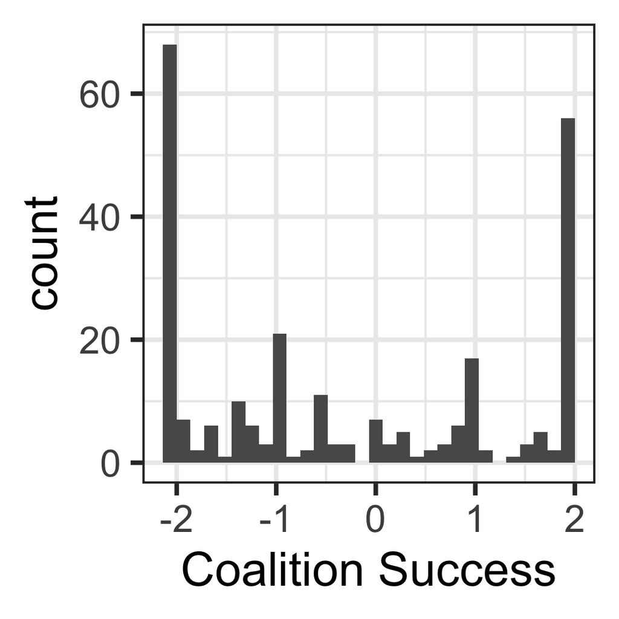

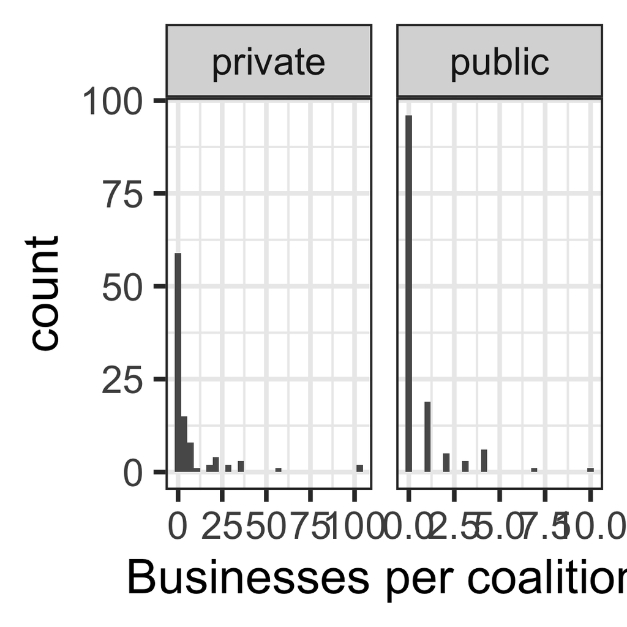

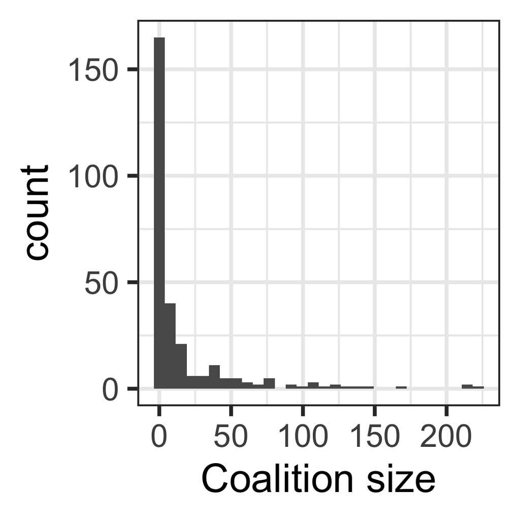

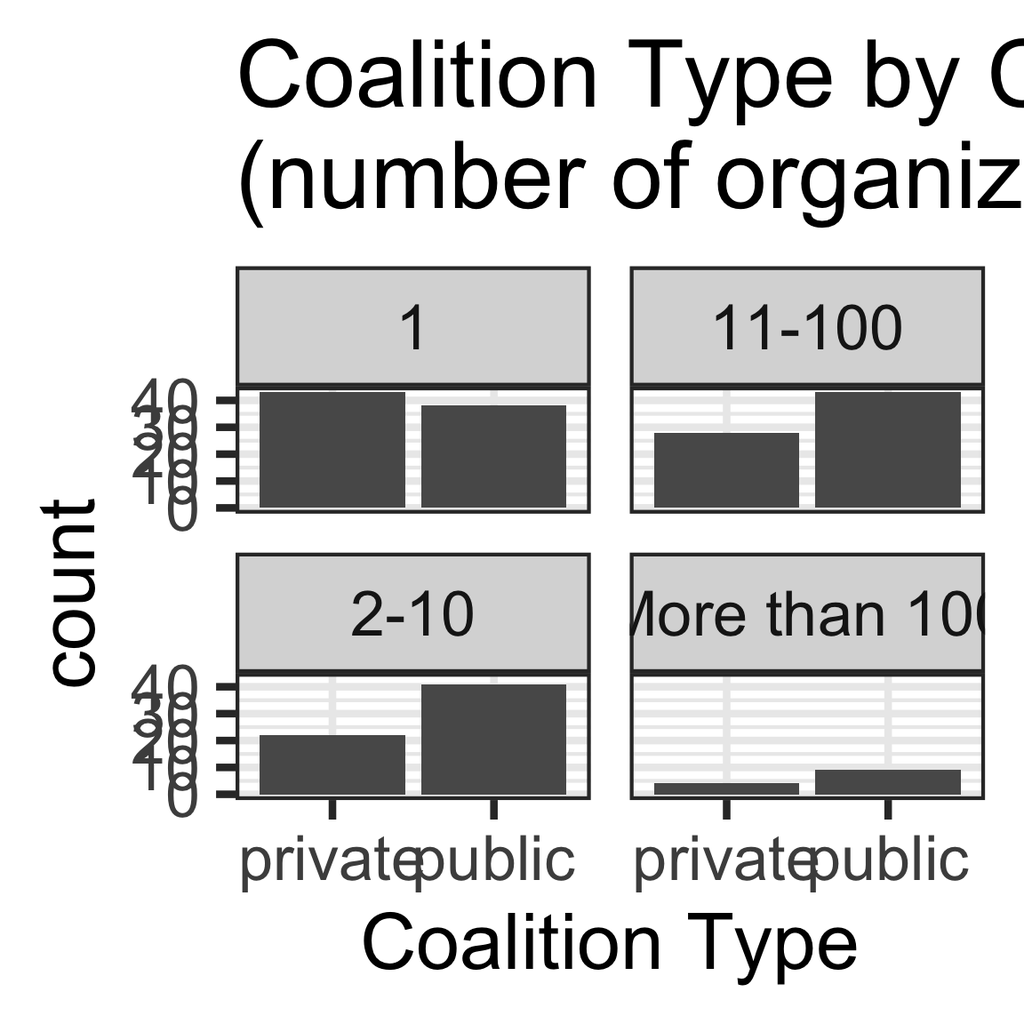

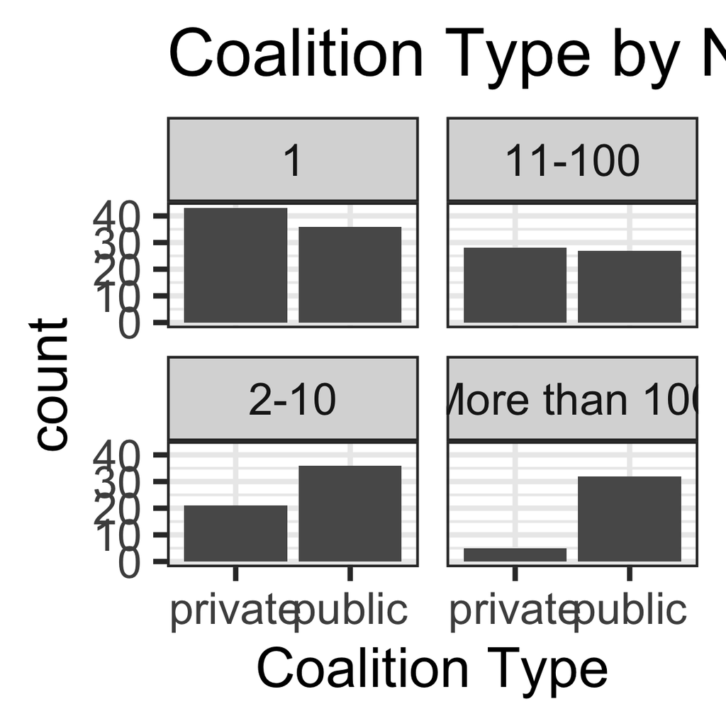

Figure 1.2: Hand-coded Data by Coalition

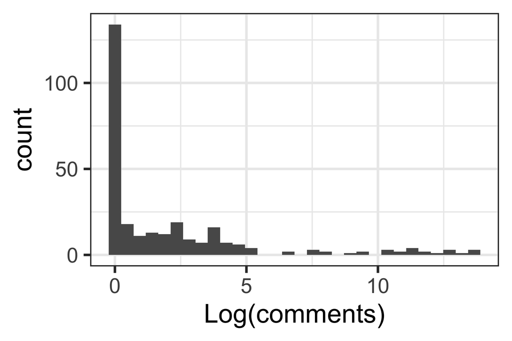

Figure 1.3: Number of Comments Linked to Hand-Coded Coalitions

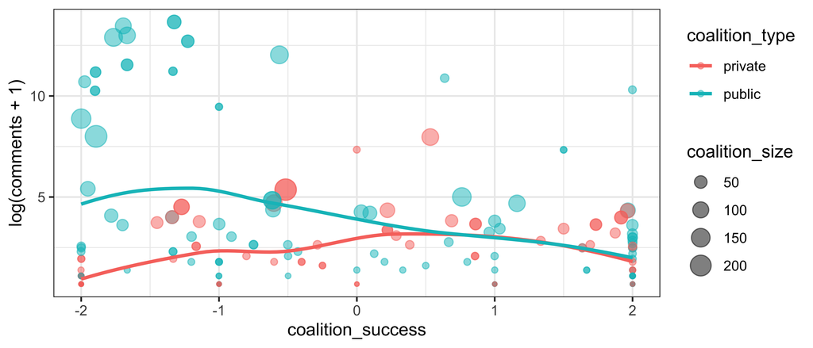

Figure 1.4: Lobbying Success by Number of Supportive Comments

## 1.3 Machine-coded Data

> IN PROGRESS

# 2 Challenges for inference

## 2.1 Non-independence

### 2.1.2 Coalitions lobbying on rules

The fact that several coalitions may lobby on the same rule is lesser form of dependence among observations. One coalition’s lobbying success is only correlated with another coalitions lobbying success to the extent that they are asking for the same or contradicting things. Because we have grouped organizations into coalitions, the causally-related asks (those organzations lobbying *because* another organization is) are largely accounted for.

# 3 Models

## 3.1 DV = Coalition success

$$y_i = \beta_0 + \beta_1 log(comments_i) + \beta_2 length_i + \beta_3 unopposed_i + \beta_4 size_i + \beta_5 business_i + \epsilon_i$$

### 3.1.1 Modeling Congressional Support as a Mediator of Lobbying Success

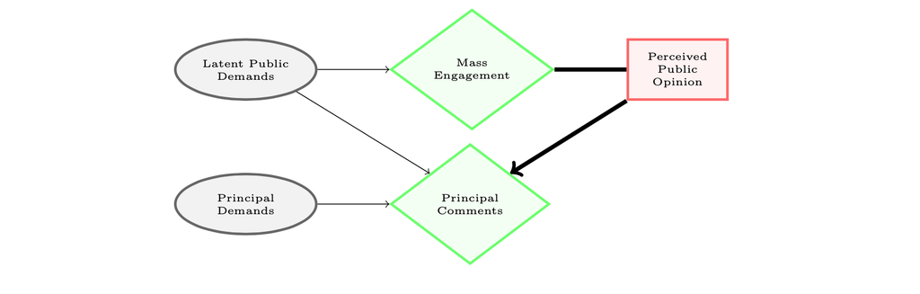

The Mediator Model: The Relationship Between Public Pressure and Congressional Oversight

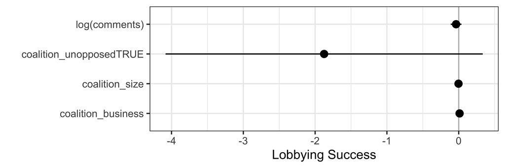

Figure 3.1: OLS Model of Coalition Lobbying Sucess with Hand-coded Data

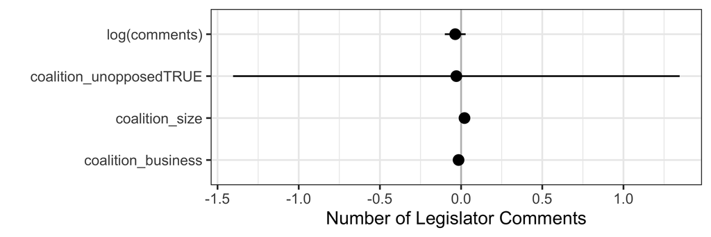

Figure 3.2: OLS Model of the Numeber of Members of Congress Per Coalition with Hand-coded Data

To assess congressional support as a mediator in the influence of public pressure campaigns on rulemaking, I estimate the average conditional marginal effect (ACME, conditional on the number of comments from Members of Congress) and average direct effect (ADE) of mass comments using mediation analysis. Model 3 in table 3.1 replaces the dependent variable (lobbying success) with the mediator variable (the number of supportive members of Congress).

Table 3.1: Lobbying Success and Congressional Support

|  | 1 | 2 | 3 |
| --- | --- | --- | --- |
| Dependent Variable | Lobbying Success | Lobbying Success | Members of Congress in Coalition |
| (Intercept) | -0.123 | -0.121 | 0.126 |
|  | (0.122) | (0.122) | (0.099) |
| log(comments) | -0.037 | -0.037 | -0.036 |
|  | (0.038) | (0.038) | (0.033) |
| coalition_business | 0.012 | 0.012 | -0.016 |
|  | (0.011) | (0.011) | (0.010) |
| coalition_size | -0.003 | -0.003 | 0.021*** |
|  | (0.004) | (0.004) | (0.004) |
| coalition_unopposedTRUE | -1.875* |  | -0.029 |
|  | (1.122) |  | (0.699) |
| coalition_congress |  | -0.010 |  |
|  |  | (0.069) |  |
| coalition_unopposed |  | -1.876* |  |
|  |  | (1.124) |  |
| Num.Obs. | 257 | 257 | 285 |
| R2 | 0.025 | 0.025 | 0.157 |
| R2 Adj. | 0.009 | 0.006 | 0.145 |
| AIC | 970.4 | 972.4 | 999.0 |
| BIC | 991.7 | 997.3 | 1020.9 |
| Log.Lik. | -479.221 | -479.211 | -493.493 |
| F | 1.610 | 1.287 | 13.075 |

* p < 0.1, ** p < 0.05, *** p < 0.01

> Mediation analysis will require adding cases where coalitions lobbied unopposed, which we are much more likely to see in the sample of rules without mass comments.

## 3.2 DV = organzation success

While it would not be appropriate to compare the lobbying success of organizations *within* a rule (because many belong to the same coalition), it may be appropriate to compare the lobbying success within the same organzation *across* rules. This limits the analysis to organzations that lobbying on multiple policies. The key variation of interest is when organzations lobby with a large amount of public support.